# COVID-19: Gross Domestic Product and vaccination rate analysis.

Paulo Rocha 919098831

03/04/2022

**Updates since last version**

- **Aims** section containing the objectives of the project was added.
- **Code Availability** section was created containing the link for the github repository with the project code and documents.
- The data was updated at March, new information regarding COVID cases, deaths and vaccination was added.
- A correlation analysis was added at the end of the **Descriptive analysis** section.
- Variables equations were added at the end of the **Descriptive analysis** section.
- Minor changes regarding the model coefficients in the **Discussion** section.
- Minor typos correction.
- Figures and tables were updated, all axis labels and variables names fixed.

# 1 Introduction

The corona virus (COVID-19) pandemic had a tremendous impact in the world [1]. Understand the factors related to the COVID-19 pandemic is key to better address future pandemics. This project analysed recent data (March 2022) collected from the World Health Organization (WHO) online platform [2] containing information at country level regarding number of cases and number of deaths overtime since 2020 until 2022, and also information regarding the most recent population vaccination levels. Data containing information about country population size was gathered from the United Nations online platform [3] to evaluate the rates of cases and deaths per population. The Gross Domestic Product (GDP), a metric used to estimate the size a country economy, was collected from the World bank [4] online platform to evaluate the impact of the country economy in vaccinations. The objective of this study was to understand the patterns regarding number of cases, deaths and case-mortality overtime and also to model the association between vaccination and cases, deaths and GDP.

# 2 Background

The COVID-19 pandemic started in the end of 2019 and by 2022 has been responsible for more than 5.8 million deaths all over the world [2]. Being a highly contagious disease the spread of the virus reached the majority of countries in the world, and even with development of the vaccine new variants of the virus still appear resulting in new waves of cases and deaths [5]. The pandemic impacted many aspects of the society such as social, educational, economic and religious [1]. To learn about how those aspects were related to the pandemic statistics, such as number of cases, deaths and vaccination, is vital to understand how the pandemic affects different countries with distinct socioeconomic characteristics, and guide future health policies.

# 3 Aims

- (Aim 1) Conduct an descriptive analysis on the COVID-19 pandemic numbers of cases and deaths, evaluating how did those numbers evolve during the years for the 6 WHO regions of the world.
- (Aim 2) Assess the association between vaccination rate, number of cases and deaths related to COVID, and the GDP by country.

# 4 Descriptive analysis

The WHO data [2] contains daily information about new and cumulative cases and deaths from January 2020 to March-2022 for 236 countries. The countries were grouped into the 6 WHO regions: Eastern Mediterranean, Europe, Africa, Western Pacific, Americas, and South-East Asia. Europe and Americas had more daily new cases and deaths for almost all the time period analyzed (Figure 1). The beginning of 2022 presented the highest values of new cases, with Europe reporting more than 2 million cases in a day. Even with the highest values of new cases the 2022 period didn’t had the highest values of new deaths showing a possible effect of vaccination.

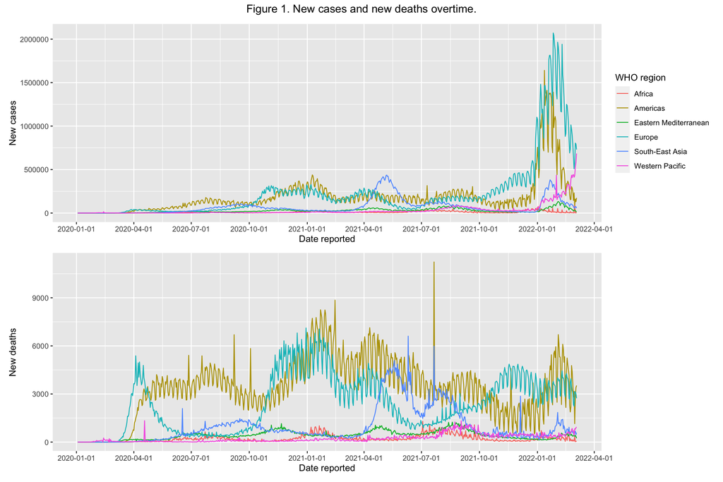

The cumulative cases overtime shows that Americas region had more cases than Europe until the beginning of 2022, showing a high increase in numbers of new cases in Europe in this period (Figure 2). At March 4th 2022, the Americas region has the highest cumulative deaths (2,637,306), 757,950 more deaths than Europe and 1,873,504 more deaths than South-East Asia.

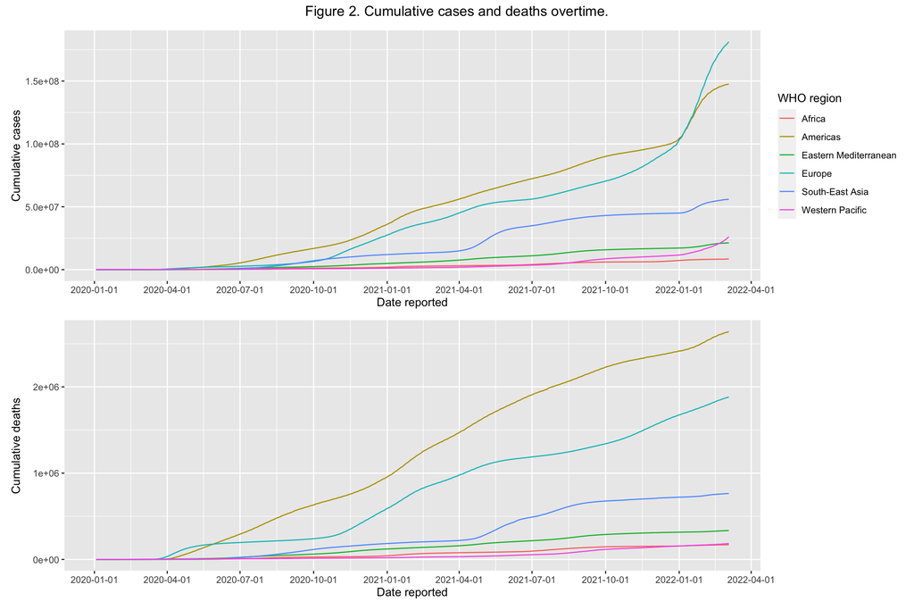

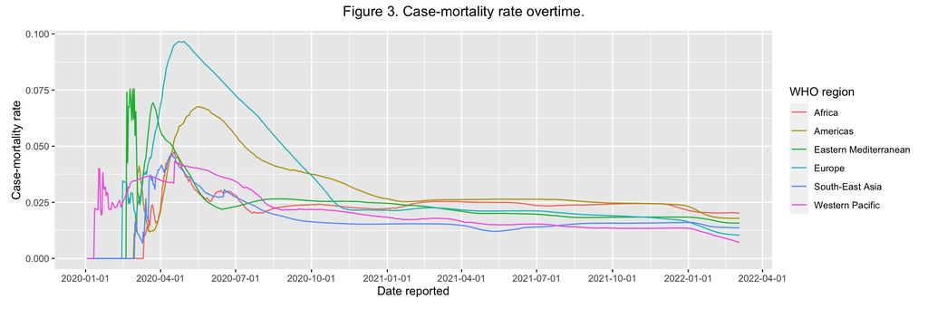

Table 1. Summary statistics, median and max values.

|  | Africa (N = 792) | Americas (N = 792) | Eastern Mediterranean (N = 792) | Europe (N = 792) | South-East Asia (N = 792) | Western Pacific (N = 792) |
| --- | --- | --- | --- | --- | --- | --- |
| **New cases** |  |  |  |  |  |  |
| median | 6.924000e+03 | 1.464560e+05 | 2.160900e+04 | 1.465090e+05 | 4.185200e+04 | 7.979000e+03 |
| max | 1.124040e+05 | 1.640223e+06 | 1.326790e+05 | 2.070460e+06 | 4.360990e+05 | 6.847750e+05 |
| **Cumulative cases** |  |  |  |  |  |  |
| median | 2.587644e+06 | 4.596567e+07 | 5.701319e+06 | 3.469518e+07 | 1.290640e+07 | 1.435020e+06 |
| max | 8.443150e+06 | 1.476559e+08 | 2.125212e+07 | 1.812753e+08 | 5.600128e+07 | 2.617924e+07 |
| **New deaths** |  |  |  |  |  |  |
| median | 1.610000e+02 | 3.384000e+03 | 4.135000e+02 | 2.214500e+03 | 5.880000e+02 | 1.245000e+02 |
| max | 1.296000e+03 | 1.123200e+04 | 1.239000e+03 | 7.118000e+03 | 6.606000e+03 | 1.330000e+03 |
| **Cumulative deaths** |  |  |  |  |  |  |
| median | 6.304100e+04 | 1.166698e+06 | 1.347420e+05 | 7.651585e+05 | 1.995730e+05 | 2.483300e+04 |
| max | 1.702340e+05 | 2.640841e+06 | 3.350040e+05 | 1.882512e+06 | 7.644100e+05 | 1.850820e+05 |
| **Case-mortality rate** |  |  |  |  |  |  |
| median | 2.379120e-02 | 2.623830e-02 | 2.151600e-02 | 2.145240e-02 | 1.546520e-02 | 1.766920e-02 |
| max | 4.743020e-02 | 6.760810e-02 | 7.570420e-02 | 9.658080e-02 | 4.677870e-02 | 4.330910e-02 |

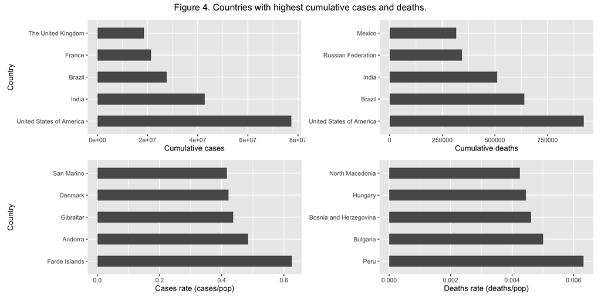

For the vaccination records, the WHO data [2] provided information regarding the most recent vaccination report for each country, in a total of 228 countries. Africa and Eastern Mediterranean WHO regions have the lowest mean values in terms of population fully vaccinated (Figure 5).

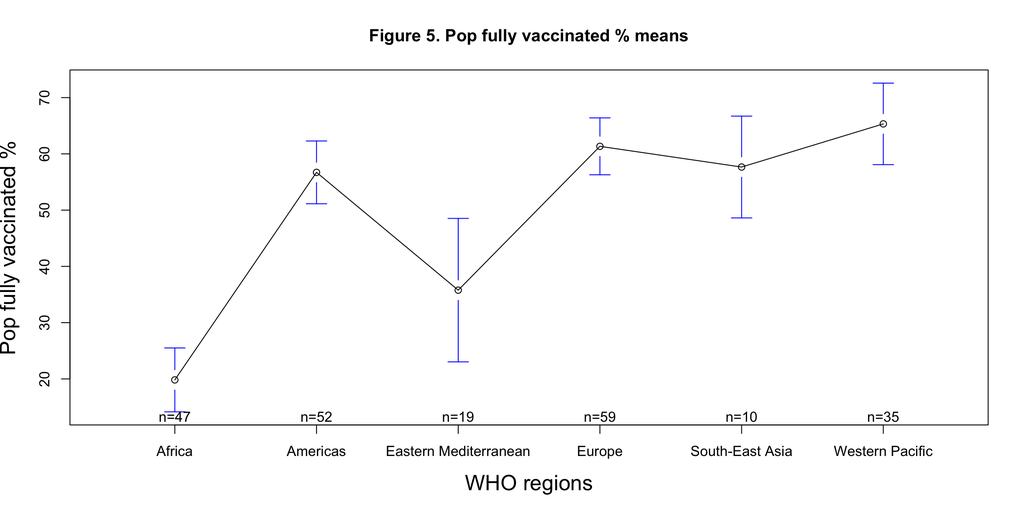

The World bank data [4] for Gross Domestic Product (GDP) contained 2020 GDP estimates for 185 countries. In terms of mean, Europe region has higher values of GDP than Africa, Eastern Mediterranean and South-East Asia (Figure 6).

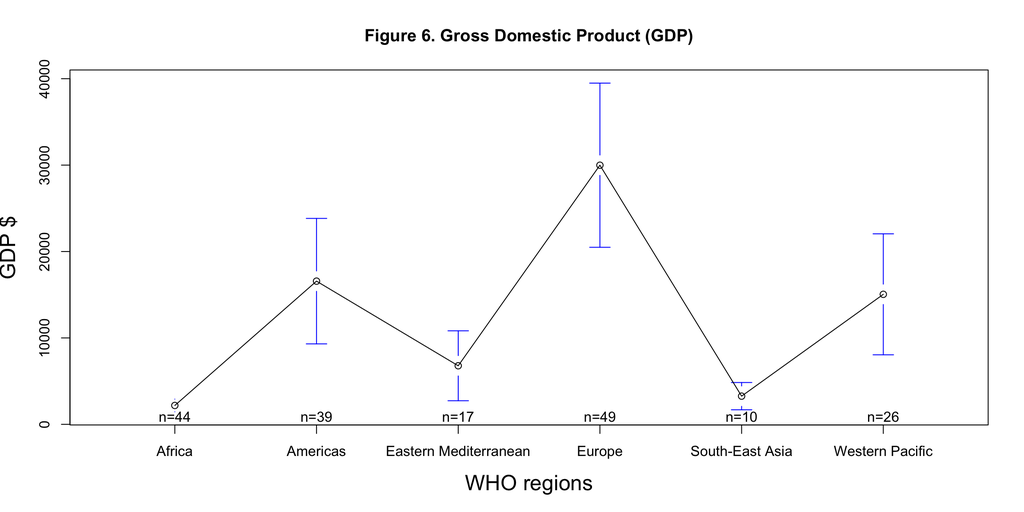

The correlation between the analyzed variables (Table 3) showed a moderate positive correlation between vaccination rate (percentage of population fully vaccinated), case rate (Equation 2), and GDP, and a weak positive correlation between vaccination rate and mortality rate (Equation 3). The mortality rate and case rate had a moderate positive correlation, and GDP had a moderate positive correlation with case rate and a weak positive correlation with mortality rate.

$$\begin{equation}
\text{Cases per pop %} = \frac{\text{cases}}{\text{population}*100}
\tag{2}
\end{equation}$$
$$\begin{equation}
\text{Deaths per pop %} = \frac{\text{deaths}}{\text{population}*100}
\tag{3}
\end{equation}$$

Table 3. Correlation matrix.

|  | Cases per pop % | Deaths per pop % | GDP | Pop fully vaccinated % |
| --- | --- | --- | --- | --- |
| Cases per pop % | 1.0000000 | 0.5809338 | 0.5363120 | 0.5276184 |
| Deaths per pop % | 0.5809338 | 1.0000000 | 0.1421446 | 0.2594510 |
| GDP | 0.5363120 | 0.1421446 | 1.0000000 | 0.4998712 |
| Pop fully vaccinated % | 0.5276184 | 0.2594510 | 0.4998712 | 1.0000000 |

# 5 Inferential analysis

For this project a Weighted Least Squares (WLS) [6,7] additive regression model will be used to evaluate the relationship, at country level, between the outcome population fully vaccinated ($Y$) and the independent variables ($X$): cases per population percentage ($X_1$), deaths per population percentage ($X_2$) and 2020 GDP ($X_3$), defined as:

$$\begin{equation}
Y = X\beta + \epsilon = \beta_0 + X_1\beta_1 + X_2\beta_2 + X_3\beta_3 + \epsilon*
\tag{4}
\end{equation}$$

The WLS model [6,7] assume that there is nonconstant variance in the errors $\epsilon*$, define the weight matrix $W$ where the diagonal $w_i=1/\sigma_i^2$ is a reciprocal of each error variance $\sigma_i^2$, and the estimate is:

$$\begin{equation}
\hat{\beta}_{WLS} = (X^TWX)^{-1}X^TWY
\tag{5}
\end{equation}$$
Each weight is inversely proportional to the error variance, where observations with small error variance will have large weight and the ones with large error variance will have small weight [7]. The model was chosen due to the presence of a continuous outcome and also because the WLS model deals with the heteroscedasticity issue that is common when applying Ordinary Least Squares models to complex real-world data.

Table 4. WLS model coefficients for Pop fully vaccinated %.

|  | Estimate | Std. Error | t value | Pr(>\|t\|) |
| --- | --- | --- | --- | --- |
| (Intercept) | 37.5980938 | 2.4884329 | 15.1091449 | 0.0000000 |
| Cases per pop % | 0.9834824 | 0.1707854 | 5.7585842 | 0.0000000 |
| Deaths per pop % | -12.3306076 | 15.5014174 | -0.7954503 | 0.4273935 |
| GDP | 0.0001493 | 0.0000475 | 3.1414714 | 0.0019641 |

# 6 Sensitivity analysis

The variables histogram showed some outliers taking into consideration the variables deaths per population percentage and 2020 GDP (Figure 7). The observations with deaths per population percentage value higher than 0.6 and 2020 GPD higher than 100,000 where removed from the data (4 observations), given the high absolute values that may influence the model.

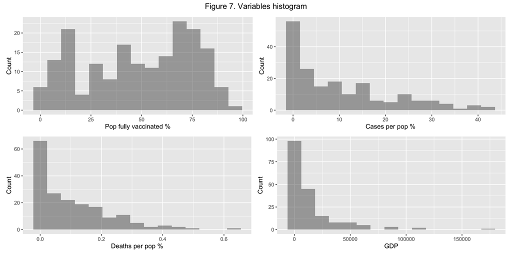

Table 5. Updated WLS model coefficients for Pop fully vaccinated %.

|  | Estimate | Std. Error | t value | Pr(>\|t\|) |
| --- | --- | --- | --- | --- |
| (Intercept) | 35.6140651 | 2.4170502 | 14.7345159 | 0.0000000 |
| Cases per pop % | 0.6093744 | 0.1996522 | 3.0521802 | 0.0026220 |
| Deaths per pop % | -1.0380971 | 16.8610038 | -0.0615679 | 0.9509764 |
| GDP | 0.0004873 | 0.0000876 | 5.5611517 | 0.0000001 |

# 7 Discussion

The project showed how different regions in the world had different characteristics regarding COVID cases, deaths and vaccination. In terms of cumulative deaths, the Americas region is the one with the highest value, while in terms of cumulative cases, the Europe region is the one with the highest value and had a great increase in 2022, showing a possible relationship with the new COVID variants. To evaluate if there is an effect in country vaccination levels given cases, deaths and GDP, the WLS was fitted based on 181 countries and showed that for a unit increase in cases per population percentage represents a 0.609 increase in fully vaccinated population percentage. That result indicated that countries with more cases cases per population tends to have a greater percentage of population fully vaccinated by March 2022. The model also showed that a $10,000 increase in GDP represents a 4.873 increase in fully vaccinated population percentage, indicating how more wealth countries will have a greater percentage of population fully vaccinated by March 2022. In conclusion, the project showed how the country number of cases and economy may explain the percentage of people fully vaccinated, that indicated how socioeconomic factors impacts the population health in a pandemic period. Analysis regarding those factors may advise international organizations, as United Nations, to better address the vaccination disparities in the world.

# Acknowledgement

None.

# 8 Code Availability

All the code used to perform the analysis of this project is available at the github repository https://github.com/PauloHARocha/COVID-19-Gross-Domestic-Product-and-vaccination-rate-analysis.

# Reference

[1] Das, K., Behera, R. L., & Paital, B. (2022). Socio-economic impact of COVID-19. In COVID-19 in the Environment (pp. 153-190). Elsevier.

[2] WHO COVID-19 Dashboard. Geneva: World Health Organization, 2020. Available online: https://covid19.who.int/ (last cited: 02/17/2022)

[3] United Nations, Department of Economic and Social Affairs, Population Division (2019). World Population Prospects 2019: Data Booket. ST/ESA/SER.A/424.

[4] The World Bank, World Development Indicators (2020). GDP per capita, Atlas method [Data file]. Retrieved from https://data.worldbank.org/indicator/NY.GDP.PCAP.CD

[5] Thakur, V., Bhola, S., Thakur, P., Patel, S. K. S., Kulshrestha, S., Ratho, R. K., & Kumar, P. (2021). Waves and variants of SARS-CoV-2: understanding the causes and effect of the COVID-19 catastrophe. Infection, 1-16.

[6] Strutz, T. (2011). Data fitting and uncertainty: A practical introduction to weighted least squares and beyond. Wiesbaden, Germany: Vieweg+ Teubner.

[7] 13.1 - weighted least squares: Stat 501. PennState: Statistics Online Courses. (n.d.). Retrieved February 17, 2022, from https://online.stat.psu.edu/stat501/lesson/13/13.1